# R Notebook

```r
library(dplyr)
library(tidyverse)
```

```r
players=read.csv("FIFA.csv")

players_2=players[,c("Position","Crossing", "Finishing","Heading.Accuracy","Short.Passing", "Volleys", "Dribbling", "Curve",              "FK.Accuracy","Long.Passing", "Ball.Control", "Acceleration", "Sprint.Speed","Agility","Reactions","Balance","Shot.Power","Jumping",   "Stamina","Strength","Long.Shots", "Aggression", "Interceptions", "Positioning","Vision","Penalties", "Composure",               "Defensive.Awareness", "Standing.Tackle", "Sliding.Tackle")]
colnames(players_2)
```

```
 [1] "Position"            "Crossing"
 [3] "Finishing"           "Heading.Accuracy"
 [5] "Short.Passing"       "Volleys"
 [7] "Dribbling"           "Curve"
 [9] "FK.Accuracy"         "Long.Passing"
[11] "Ball.Control"        "Acceleration"
[13] "Sprint.Speed"        "Agility"
[15] "Reactions"           "Balance"
[17] "Shot.Power"          "Jumping"
[19] "Stamina"             "Strength"
[21] "Long.Shots"          "Aggression"
[23] "Interceptions"       "Positioning"
[25] "Vision"              "Penalties"
[27] "Composure"           "Defensive.Awareness"
[29] "Standing.Tackle"     "Sliding.Tackle"
```

```r
players_2
```

| Position | Crossing | Finishing | Heading.Accuracy | Short.Passing | Volleys | Dribbling | Curve | FK.Accuracy | Long.Passing | Ball.Control | Acceleration | Sprint.Speed | Agility | Reactions | Balance | Shot.Power | Jumping | Stamina | Strength | Long.Shots | Aggression | Interceptions | Positioning | Vision | Penalties | Composure | Defensive.Awareness | Standing.Tackle | Sliding.Tackle |
| --- | --- | --- | --- | --- | --- | --- | --- | --- | --- | --- | --- | --- | --- | --- | --- | --- | --- | --- | --- | --- | --- | --- | --- | --- | --- | --- | --- | --- | --- |
| RM | 67 | 60 | 50 | 67 | 56 | 74 | 59 | 62 | 58 | 70 | 84 | 84 | 83 | 65 | 76 | 68 | 75 | 75 | 61 | 61 | 42 | 31 | 65 | 63 | 66 | 61 | 35 | 11 | 18 |
| ST | 68 | 87 | 89 | 75 | 88 | 75 | 75 | 76 | 52 | 79 | 74 | 76 | 74 | 88 | 59 | 88 | 88 | 90 | 79 | 77 | 84 | 54 | 92 | 75 | 85 | 80 | 57 | 48 | 39 |
| LM | 54 | 59 | 42 | 73 | 59 | 77 | 74 | 64 | 50 | 75 | 78 | 76 | 84 | 61 | 80 | 62 | 60 | 53 | 54 | 58 | 43 | 31 | 56 | 65 | 50 | 59 | 30 | 23 | 24 |
| RW | 76 | 72 | 45 | 74 | 72 | 84 | 81 | 72 | 66 | 80 | 91 | 91 | 86 | 82 | 79 | 80 | 74 | 83 | 64 | 74 | 74 | 55 | 81 | 75 | 73 | 79 | 45 | 54 | 38 |
| LCM | 90 | 84 | 62 | 83 | 90 | 86 | 89 | 86 | 81 | 90 | 55 | 52 | 78 | 84 | 76 | 86 | 46 | 65 | 64 | 92 | 60 | 55 | 80 | 83 | 81 | 87 | 52 | 41 | 44 |
| RS | 46 | 87 | 67 | 74 | 82 | 75 | 77 | 62 | 49 | 78 | 80 | 88 | 75 | 83 | 67 | 93 | 70 | 78 | 91 | 83 | 82 | 41 | 86 | 68 | 80 | 83 | 45 | 38 | 30 |
| RW | 68 | 65 | 37 | 73 | 55 | 85 | 70 | 60 | 60 | 81 | 86 | 82 | 92 | 78 | 92 | 67 | 45 | 75 | 35 | 65 | 48 | 30 | 73 | 69 | 58 | 78 | 38 | 33 | 27 |
| LCM | 58 | 68 | 42 | 71 | 58 | 74 | 56 | 45 | 66 | 73 | 78 | 77 | 74 | 70 | 71 | 63 | 56 | 73 | 66 | 64 | 58 | 61 | 67 | 63 | 56 | 68 | 43 | 67 | 51 |
| RW | 69 | 73 | 66 | 71 | 66 | 85 | 84 | 56 | 67 | 83 | 81 | 78 | 83 | 79 | 67 | 74 | 63 | 77 | 71 | 74 | 53 | 32 | 74 | 75 | 67 | 84 | 35 | 34 | 32 |
| RB | 77 | 67 | 67 | 78 | 61 | 78 | 70 | 44 | 72 | 74 | 81 | 81 | 74 | 77 | 75 | 78 | 64 | 88 | 69 | 70 | 76 | 72 | 78 | 76 | 68 | 77 | 72 | 71 | 72 |

[output cut: 990 more lines]

```r
Attack=c("LW", "LF", "RW","RF", "CF", "ST", "CAM")
Defense=c("RB", "RWB", "LB", "LWB", "CB")
index_attack=which(players_2$Position %in%(Attack))
index_attack
```

```
   [1]    2    4    7    9   12   13   17   20   23   25
  [11]   26   29   32   33   40   46   47   50   52   53
  [21]   63   66   67   68   71   72   79   80   81   82
  [31]   87   88   89   95   98   99  100  103  104  109
  [41]  126  130  136  137  138  140  143  144  145  146
  [51]  152  153  161  185  187  191  196  198  199  206
  [61]  211  214  217  223  224  226  228  229  233  234
  [71]  235  243  245  249  258  259  263  265  266  271
  [81]  273  275  280  283  285  286  289  291  296  310
  [91]  316  317  322  323  326  329  332  333  338  340
 [101]  342  343  346  349  350  357  366  368  372  374
 [111]  376  381  382  383  388  389  391  401  406  407
 [121]  409  412  414  417  423  426  427  429  432  435
 [131]  436  438  439  443  445  447  451  462  474  477
 [141]  479  480  482  491  493  494  497  508  509  517
```

[output cut: 86 more lines]

```r
players_2[index_attack, "Position"]="A"
players_2
```

| Position | Crossing | Finishing | Heading.Accuracy | Short.Passing | Volleys | Dribbling | Curve | FK.Accuracy | Long.Passing | Ball.Control | Acceleration | Sprint.Speed | Agility | Reactions | Balance | Shot.Power | Jumping | Stamina | Strength | Long.Shots | Aggression | Interceptions | Positioning | Vision | Penalties | Composure | Defensive.Awareness | Standing.Tackle | Sliding.Tackle |
| --- | --- | --- | --- | --- | --- | --- | --- | --- | --- | --- | --- | --- | --- | --- | --- | --- | --- | --- | --- | --- | --- | --- | --- | --- | --- | --- | --- | --- | --- |
| RM | 67 | 60 | 50 | 67 | 56 | 74 | 59 | 62 | 58 | 70 | 84 | 84 | 83 | 65 | 76 | 68 | 75 | 75 | 61 | 61 | 42 | 31 | 65 | 63 | 66 | 61 | 35 | 11 | 18 |
| A | 68 | 87 | 89 | 75 | 88 | 75 | 75 | 76 | 52 | 79 | 74 | 76 | 74 | 88 | 59 | 88 | 88 | 90 | 79 | 77 | 84 | 54 | 92 | 75 | 85 | 80 | 57 | 48 | 39 |
| LM | 54 | 59 | 42 | 73 | 59 | 77 | 74 | 64 | 50 | 75 | 78 | 76 | 84 | 61 | 80 | 62 | 60 | 53 | 54 | 58 | 43 | 31 | 56 | 65 | 50 | 59 | 30 | 23 | 24 |
| A | 76 | 72 | 45 | 74 | 72 | 84 | 81 | 72 | 66 | 80 | 91 | 91 | 86 | 82 | 79 | 80 | 74 | 83 | 64 | 74 | 74 | 55 | 81 | 75 | 73 | 79 | 45 | 54 | 38 |
| LCM | 90 | 84 | 62 | 83 | 90 | 86 | 89 | 86 | 81 | 90 | 55 | 52 | 78 | 84 | 76 | 86 | 46 | 65 | 64 | 92 | 60 | 55 | 80 | 83 | 81 | 87 | 52 | 41 | 44 |
| RS | 46 | 87 | 67 | 74 | 82 | 75 | 77 | 62 | 49 | 78 | 80 | 88 | 75 | 83 | 67 | 93 | 70 | 78 | 91 | 83 | 82 | 41 | 86 | 68 | 80 | 83 | 45 | 38 | 30 |
| A | 68 | 65 | 37 | 73 | 55 | 85 | 70 | 60 | 60 | 81 | 86 | 82 | 92 | 78 | 92 | 67 | 45 | 75 | 35 | 65 | 48 | 30 | 73 | 69 | 58 | 78 | 38 | 33 | 27 |
| LCM | 58 | 68 | 42 | 71 | 58 | 74 | 56 | 45 | 66 | 73 | 78 | 77 | 74 | 70 | 71 | 63 | 56 | 73 | 66 | 64 | 58 | 61 | 67 | 63 | 56 | 68 | 43 | 67 | 51 |
| A | 69 | 73 | 66 | 71 | 66 | 85 | 84 | 56 | 67 | 83 | 81 | 78 | 83 | 79 | 67 | 74 | 63 | 77 | 71 | 74 | 53 | 32 | 74 | 75 | 67 | 84 | 35 | 34 | 32 |
| RB | 77 | 67 | 67 | 78 | 61 | 78 | 70 | 44 | 72 | 74 | 81 | 81 | 74 | 77 | 75 | 78 | 64 | 88 | 69 | 70 | 76 | 72 | 78 | 76 | 68 | 77 | 72 | 71 | 72 |

[output cut: 990 more lines]

```r
index_defense=which(players_2$Position %in%(Defense))
index_defense
```

```
   [1]   10   15   18   19   22   34   37   39   42   43
  [11]   54   61   69   75   93   94  101  102  105  110
  [21]  112  117  118  120  124  127  131  134  139  150
  [31]  162  167  171  172  175  178  179  182  183  184
  [41]  190  194  197  203  204  205  209  212  215  222
  [51]  225  230  238  242  248  250  253  260  261  272
  [61]  282  284  287  288  297  298  301  306  308  315
  [71]  318  321  325  334  336  341  344  345  364  369
  [81]  370  379  385  392  399  403  408  410  413  415
  [91]  422  424  431  440  441  444  448  456  458  459
 [101]  463  464  467  469  471  472  476  486  488  492
 [111]  495  498  510  511  516  524  525  526  529  533
 [121]  539  543  553  563  564  572  573  575  583  584
 [131]  600  605  608  611  614  622  632  666  668  670
 [141]  671  673  679  690  691  697  698  703  707  712
```

[output cut: 86 more lines]

```r
players_2[index_defense, "Position"]="D"
players_2=players_2[c(index_attack,index_defense),]
players_2
```

|  | Position | Crossing | Finishing | Heading.Accuracy | Short.Passing | Volleys | Dribbling | Curve | FK.Accuracy | Long.Passing | Ball.Control | Acceleration | Sprint.Speed | Agility | Reactions | Balance | Shot.Power | Jumping | Stamina | Strength | Long.Shots | Aggression | Interceptions | Positioning | Vision | Penalties | Composure | Defensive.Awareness | Standing.Tackle | … |
| --- | --- | --- | --- | --- | --- | --- | --- | --- | --- | --- | --- | --- | --- | --- | --- | --- | --- | --- | --- | --- | --- | --- | --- | --- | --- | --- | --- | --- | --- | --- |
| 2 | A | 68 | 87 | 89 | 75 | 88 | 75 | 75 | 76 | 52 | 79 | 74 | 76 | 74 | 88 | 59 | 88 | 88 | 90 | 79 | 77 | 84 | 54 | 92 | 75 | 85 | 80 | 57 | 48 | … |
| 4 | A | 76 | 72 | 45 | 74 | 72 | 84 | 81 | 72 | 66 | 80 | 91 | 91 | 86 | 82 | 79 | 80 | 74 | 83 | 64 | 74 | 74 | 55 | 81 | 75 | 73 | 79 | 45 | 54 | … |
| 7 | A | 68 | 65 | 37 | 73 | 55 | 85 | 70 | 60 | 60 | 81 | 86 | 82 | 92 | 78 | 92 | 67 | 45 | 75 | 35 | 65 | 48 | 30 | 73 | 69 | 58 | 78 | 38 | 33 | … |
| 9 | A | 69 | 73 | 66 | 71 | 66 | 85 | 84 | 56 | 67 | 83 | 81 | 78 | 83 | 79 | 67 | 74 | 63 | 77 | 71 | 74 | 53 | 32 | 74 | 75 | 67 | 84 | 35 | 34 | … |
| 12 | A | 69 | 75 | 58 | 72 | 59 | 79 | 64 | 45 | 69 | 77 | 89 | 87 | 89 | 70 | 82 | 67 | 73 | 64 | 48 | 70 | 48 | 19 | 68 | 67 | 74 | 73 | 23 | 32 | … |
| 13 | A | 65 | 78 | 85 | 70 | 73 | 76 | 64 | 54 | 44 | 76 | 79 | 87 | 72 | 79 | 64 | 79 | 90 | 79 | 81 | 65 | 75 | 34 | 82 | 64 | 77 | 71 | 38 | 31 | … |
| 17 | A | 56 | 61 | 28 | 67 | 51 | 75 | 66 | 70 | 53 | 73 | 71 | 71 | 76 | 63 | 81 | 64 | 35 | 56 | 61 | 57 | 57 | 21 | 62 | 64 | 61 | 64 | 19 | 20 | … |
| 20 | A | 64 | 61 | 37 | 66 | 49 | 80 | 58 | 38 | 42 | 73 | 96 | 91 | 95 | 63 | 88 | 64 | 90 | 63 | 61 | 53 | 58 | 18 | 58 | 53 | 48 | 60 | 27 | 28 | … |
| 23 | A | 59 | 57 | 41 | 61 | 51 | 72 | 60 | 61 | 47 | 66 | 94 | 89 | 91 | 63 | 74 | 65 | 37 | 68 | 39 | 59 | 36 | 17 | 61 | 60 | 59 | 58 | 20 | 24 | … |
| 25 | A | 50 | 76 | 75 | 73 | 76 | 73 | 61 | 30 | 35 | 75 | 72 | 71 | 68 | 68 | 62 | 77 | 79 | 70 | 85 | 69 | 57 | 24 | 75 | 58 | 58 | 69 | 27 | 24 | … |

[output cut: 990 more lines]

Séparation en jeu de données test et validation

```r
n=length(players_2[,1])
len.app=as.integer(3*n/4)
tirage=sample(seq(1,n),len.app, replace=FALSE)
train=players_2[tirage,]
x_train= train[,2:length(train[1,])]
y_train= train[,1]
test=players_2[-tirage,]
x_test= test[,2:length(test[1,])]
y_test= test[,1]
```

```r
#install.packages("keras")
library(keras)
```

```r
#Création des différents modèles
single_perceptron<-function(x_train, activation='sigmoid', final_units=1){
    model = keras_model_sequential()
    model %>% layer_dense(units=final_units, activation=activation, input_shape=length(x_train[1,]))
return(model)
}
two_layers<-function(x_train, activation='sigmoid', final_units=1){
    model = keras_model_sequential()
    model %>% layer_dense(units=as.integer(length(x_train[1,])/2), activation=activation, input_shape=length(x_train[1,])) %>% layer_dense(units=final_units, activation=activation)
return(model)
}
three_layers<-function(x_train, activation='sigmoid', final_units=1){
    model = keras_model_sequential()
    model %>% layer_dense(units=length(x_train[1,]), activation=activation, input_shape=length(x_train[1,])) %>% layer_dense(units=as.integer(length(x_train[1,])/2), activation=activation) %>% layer_dense(units=final_units, activation=activation)
return(model)
}
```

```r
compile_fit<-function(fun, activation, x=x_train,y=y_train, loss="binary_crossentropy", final_units=1, epochs=30, verbose=0, batch_size=5, validation_split=0.3){
  # Permet de compiler et d'exécuter un modèle
  model=fun(x,activation,final_units)
  model %>% compile(loss=loss,optimizer="adam",metrics='accuracy')
  summary(model)
  history=model%>% fit(x=x, y=y, epochs=epochs, batch_size=batch_size,validation_split=validation_split, verbose=verbose)
  return(list(model,history))
}
```

```r
single1 = compile_fit(single_perceptron, "sigmoid", verbose=2)
single1[[1]] %>% evaluate(x_test,y_test)
plot(single1[[2]])
```

[output not shown]

## SVM

On considère prmièrement les données sont non-séparables

```r
library(e1071)
```

```r
svm_player <- train
svm_player$Position <- as.factor(svm_player$Position)
#mod.svm.lin = svm(Position~.,data=svm_player,kernel="linear",cost=1)
#plot(mod.svm.lin,data = svm_player, Crossing~Finishing)
#plot(mod.svm.lin,data = svm_player, Crossing~Dribbling)
#plot(mod.svm.lin,data = svm_player, Crossing~Volleys)
```

```r
library(caret)
library(kernlab)
```

```r
svm_player_omit <- na.omit(svm_player)
```

```r
C <- c(0.001,0.01,1,10,100,1000)
gr.lin <- expand.grid(C=C)
ctrl <- trainControl(method="cv")
train.mod.lin <- train(Position~.,data=svm_player_omit,method="svmLinear",trControl=ctrl,tuneGrid=gr.lin)
```

```r
train.mod.lin
```

```
Support Vector Machines with Linear Kernel

3055 samples
  29 predictor
   2 classes: 'A', 'D'

No pre-processing
Resampling: Cross-Validated (10 fold)
Summary of sample sizes: 2749, 2750, 2750, 2750, 2749, 2750, ...
Resampling results across tuning parameters:

  C      Accuracy   Kappa
  1e-03  0.9816726  0.9633278
  1e-02  0.9872345  0.9744470
  1e+00  0.9878881  0.9757469
  1e+01  0.9872345  0.9744407
  1e+02  0.9875635  0.9750973
  1e+03  0.9872356  0.9744427

Accuracy was used to select the optimal model using
 the largest value.
The final value used for the model was C = 1.
```

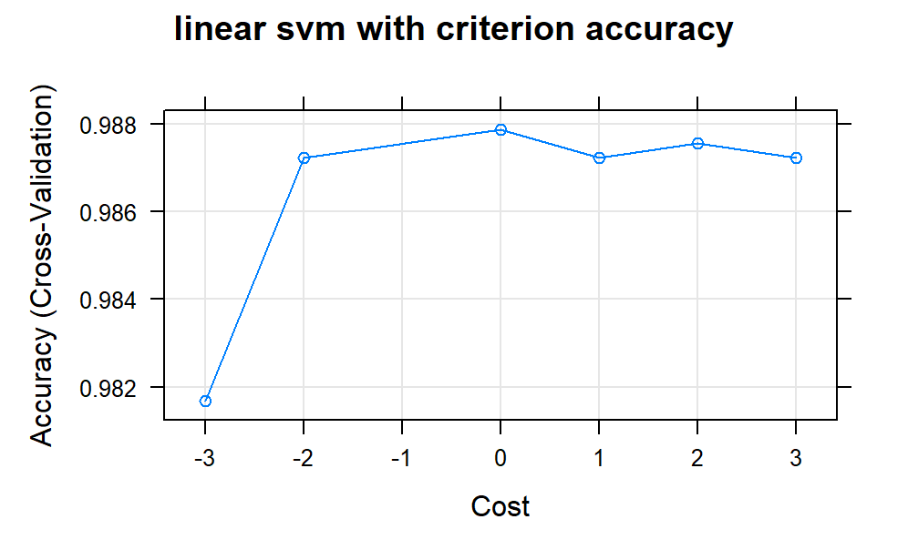

```r
plot(train.mod.lin, metric = "Accuracy",xTrans=log10,main = "linear svm with criterion accuracy")
```

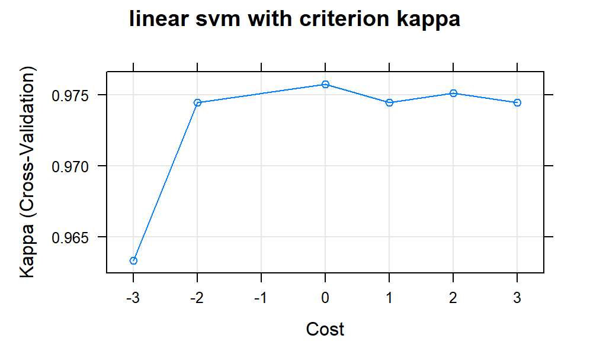

```r
plot(train.mod.lin, metric = "Kappa",xTrans=log10,main = "linear svm with criterion kappa")
```

```r
#mod.svm.rad <- svm(Position~.,data=svm_player,kernel="radial",gamma=1,cost=1)
#plot(mod.svm.rad,data = svm_player, Crossing~Finishing)
```

**remark**

storing the kernel matrix requires memory that scales quadratically with the number of data points. Training time for traditional SVM algorithms also scales superlinearly with the number of data points. So, svm method is not really feasible for large data sets

```r
C <- c(0.001,0.01,1,10,100,1000)
sigma <- c(0.1,0.5,1,2,3,4)
gr <- expand.grid(C=C,sigma=sigma)
ctrl <- trainControl(method="cv")
train.mod.rad <- train(Position~.,data=svm_player_omit,method="svmRadial",trControl=ctrl,tuneGrid=gr)
```

it has to notice that the running time of the radial method is much longer than the basic linear svm method

```r
train.mod.rad
```

```
Support Vector Machines with Radial Basis Function Kernel

3050 samples
  29 predictor
   2 classes: 'A', 'D'

No pre-processing
Resampling: Cross-Validated (10 fold)
Summary of sample sizes: 2746, 2745, 2745, 2745, 2745, 2745, ...
Resampling results across tuning parameters:

  C      sigma  Accuracy   Kappa
  1e-03  0.1    0.5167213  0.000000000
  1e-03  0.5    0.5167213  0.000000000
 1e-03 1.0   0.5167213 0.000000000
 1e-03 2.0   0.5167213 0.000000000
 1e-03 3.0   0.5167213 0.000000000
 1e-03 4.0   0.5167213 0.000000000
 1e-02 0.1   0.9711507 0.942188678
 1e-02 0.5   0.5167213 0.000000000
 1e-02 1.0   0.5167213 0.000000000
 1e-02 2.0   0.5167213 0.000000000
 1e-02 3.0   0.5167213 0.000000000
 1e-02 4.0   0.5167213 0.000000000
 1e+00 0.1   0.9878688 0.975717127
 1e+00 0.5   0.9141175 0.827144850
 1e+00 1.0   0.6229597 0.225558249
 1e+00 2.0   0.5180318 0.002802345
 1e+00 3.0   0.5180318 0.002802345
 1e+00 4.0   0.5180318 0.002802345
 1e+01 0.1   0.9865573 0.973092654
 1e+01 0.5   0.9177209 0.834430465
 1e+01 1.0   0.6586986 0.300684701
 1e+01 2.0   0.5180318 0.002802345
 1e+01 3.0   0.5180318 0.002802345
 1e+01 4.0   0.5180318 0.002802345
 1e+02 0.1   0.9865573 0.973092654
 1e+02 0.5   0.9177209 0.834430465
 1e+02 1.0   0.6586986 0.300684701
 1e+02 2.0   0.5180318 0.002802345
 1e+02 3.0   0.5180318 0.002802345
 1e+02 4.0   0.5180318 0.002802345
 1e+03 0.1   0.9865573 0.973092654
 1e+03 0.5   0.9177209 0.834430465
 1e+03 1.0   0.6586986 0.300684701
 1e+03 2.0   0.5180318 0.002802345
 1e+03 3.0   0.5180318 0.002802345
 1e+03 4.0   0.5180318 0.002802345

Accuracy was used to select the optimal model using
 the largest value.
The final values used for the model were sigma = 0.1 and
 C = 1.
```

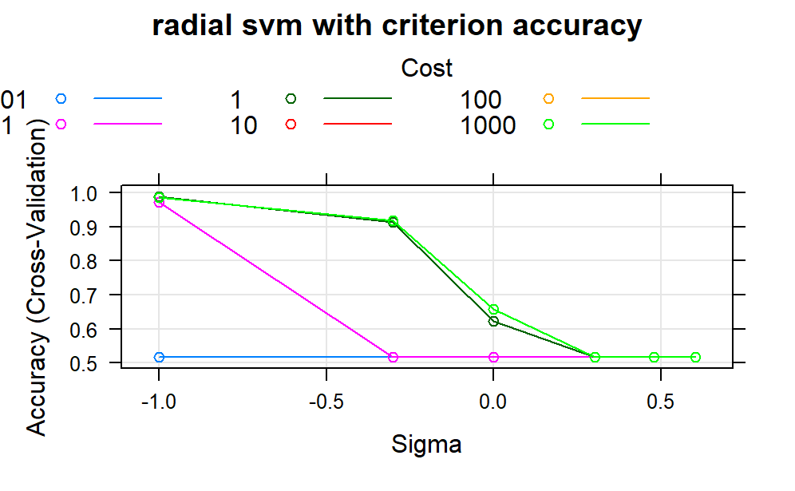

```r
plot(train.mod.rad, metric = "Accuracy",xTrans=log10,main = "radial svm with criterion accuracy")
```

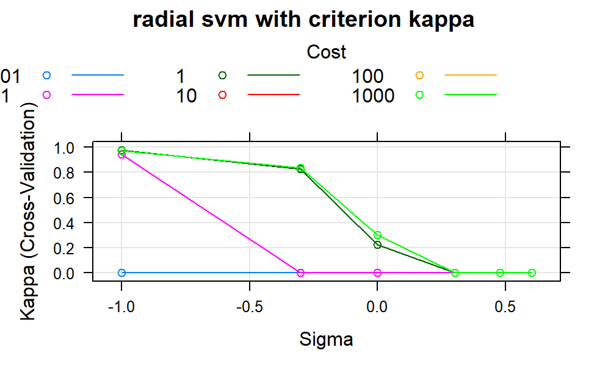

```r
plot(train.mod.rad, metric = "Kappa",xTrans=log10,main = "radial svm with criterion kappa")
```

But we have risk that the R session be explosed, than we try to find a more classical way to apply the traing process.

```r
#tune.out <- tune(svm,Position~.,data=svm_player,kernel="radial",ranges=list(cost=c(0.1,1,10,100,1000),gamma=c(0.5,1,2,3,4)))
summary(tune.out)
```

(gamma = 1/sigma)

else we use linear svm, it is precise enough

```r
tune.out <- tune(svm,Position~.,data=svm_player,kernel="linear",ranges=list(cost=c(0.1,1,10,100,1000)))
```

```
WARNING: reaching max number of iterations

WARNING: reaching max number of iterations

WARNING: reaching max number of iterations

WARNING: reaching max number of iterations
```

```r
summary(tune.out)
```

```
Parameter tuning of ‘svm’:

- sampling method: 10-fold cross validation

- best parameters:
```

|  | cost |
| --- | --- |
|  | 0.1 |

```
- best performance: 0.01180447

- Detailed performance results:
```

| cost | error | dispersion |
| --- | --- | --- |
| 1e-01 | 0.01180447 | 0.005808161 |
| 1e+00 | 0.01280903 | 0.005267979 |
| 1e+01 | 0.01379313 | 0.004908705 |
| 1e+02 | 0.01347159 | 0.004847396 |
| 1e+03 | 0.01347159 | 0.004847396 |

```
NA
```

```r
test$Position <- as.factor(test$Position)
test1 = na.omit(test)
prev <- predict(tune.out$best.model,newdata=test1)
confusionMatrix(data = prev, reference = test1$Position)
```

```
Confusion Matrix and Statistics

          Reference
Prediction   A   D
         A 533   4
         D   6 475

               Accuracy : 0.9902
                 95% CI : (0.982, 0.9953)
    No Information Rate : 0.5295
    P-Value [Acc > NIR] : <2e-16

                  Kappa : 0.9803

 Mcnemar's Test P-Value : 0.7518

            Sensitivity : 0.9889
            Specificity : 0.9916
         Pos Pred Value : 0.9926
         Neg Pred Value : 0.9875
             Prevalence : 0.5295
         Detection Rate : 0.5236
   Detection Prevalence : 0.5275
      Balanced Accuracy : 0.9903

       'Positive' Class : A
```

```r
mod.final <- svm(Position~.,data=svm_player_omit,kernel="linear",cost=0.1,decision.values=TRUE,probability=TRUE)
prob <- predict(mod.final,newdata=test1,probability=TRUE,decision.values=TRUE)
prob1 <- attr(prob,"probabilities")
```

now we r going to compare with the decision tree:

```r
library(rpart)

tree_train_data <- svm_player_omit
tree_test_data <- test1
set.seed(56)
arbre <- rpart(Position~.,data=tree_train_data,cp=0.0001,minsplit=2,minbucket=1)
printcp(arbre)
```

```
Classification tree:
rpart(formula = Position ~ ., data = tree_train_data, cp = 1e-04,
    minsplit = 2, minbucket = 1)

Variables actually used in tree construction:
 [1] Acceleration        Aggression
 [3] Agility             Balance
 [5] Ball.Control        Crossing
 [7] Defensive.Awareness Dribbling
 [9] Finishing           FK.Accuracy
[11] Heading.Accuracy    Interceptions
[13] Jumping             Long.Passing
[15] Long.Shots          Penalties
[17] Positioning         Reactions
[19] Short.Passing       Sliding.Tackle
```

[output cut: 22 more lines]

```r
cp_opt <- arbre$cptable[which.min(arbre$cptable[,"xerror"]),"CP"]
arbre1 <- prune(arbre,cp=cp_opt)

prev1 <- predict(arbre1,newdata=tree_test_data,type="class")
table(true=tree_test_data$Position,pred=prev1)
```

```
    pred
true   A   D
   A 528  11
   D   7 472
```

```r
gr = expand.grid(cp=c(10^-(5:0)))
ctrl <- trainControl(method="cv")
train.mod.tree = train(Position ~ .,
                data = tree_train_data,
                method = "rpart",
                trControl = ctrl,
                tuneGrid = gr)
```

```r
train.mod.tree
```

```
CART

3050 samples
  29 predictor
   2 classes: 'A', 'D'

No pre-processing
Resampling: Cross-Validated (10 fold)
Summary of sample sizes: 2745, 2745, 2744, 2746, 2745, 2745, ...
Resampling results across tuning parameters:

  cp     Accuracy   Kappa
  1e-05  0.9763815  0.9527097
  1e-04  0.9763815  0.9527097
  1e-03  0.9790098  0.9579845
  1e-02  0.9773694 0.9547086
 1e-01 0.9501616 0.9003331
 1e+00 0.5167214 0.0000000

Accuracy was used to select the optimal model using
 the largest value.
The final value used for the model was cp = 0.001.
```

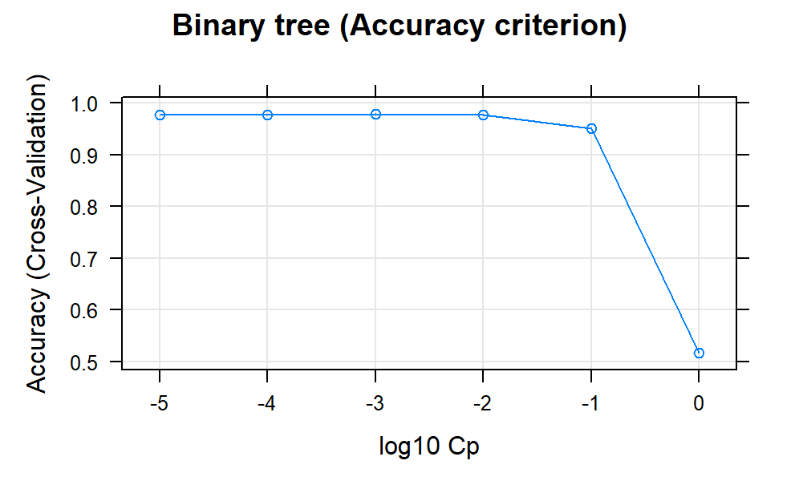

```r
plot(train.mod.tree, metric = "Accuracy", xTrans = log10, xlab = "log10 Cp", main = "Binary tree (Accuracy criterion)")
```

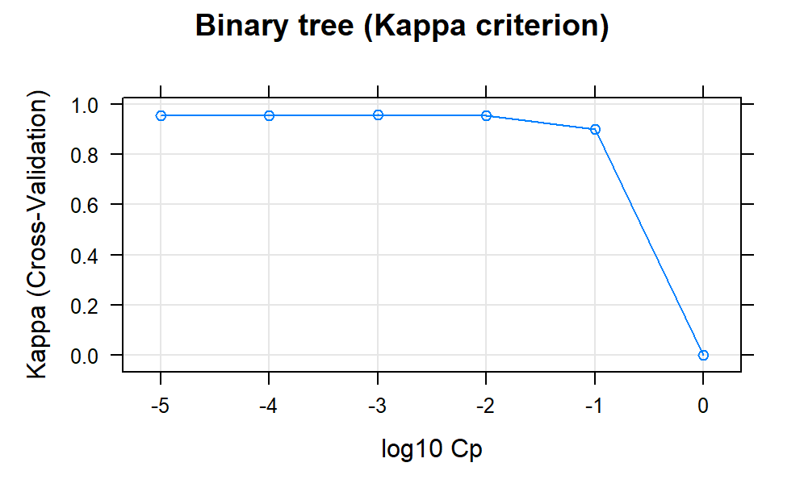

```r
plot(train.mod.tree, metric = "Kappa", xTrans = log10, xlab = "log10 Cp", main = "Binary tree (Kappa criterion)")
```

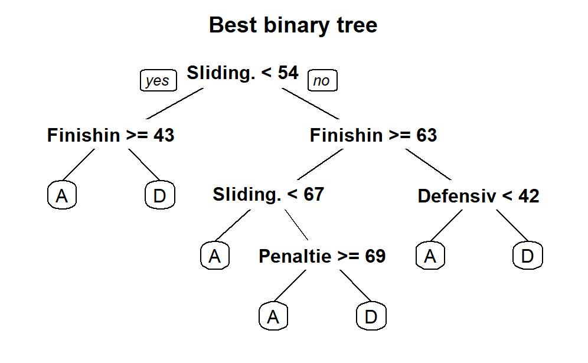

```r
library(rpart.plot)
prp(train.mod.tree$finalModel, main = "Best binary tree")
```

```r
pred.tree <- predict(train.mod.tree,tree_test_data)
```

we gonna plot the two ROC curves and compare the accuracy.

```r
library(plotROC)
```

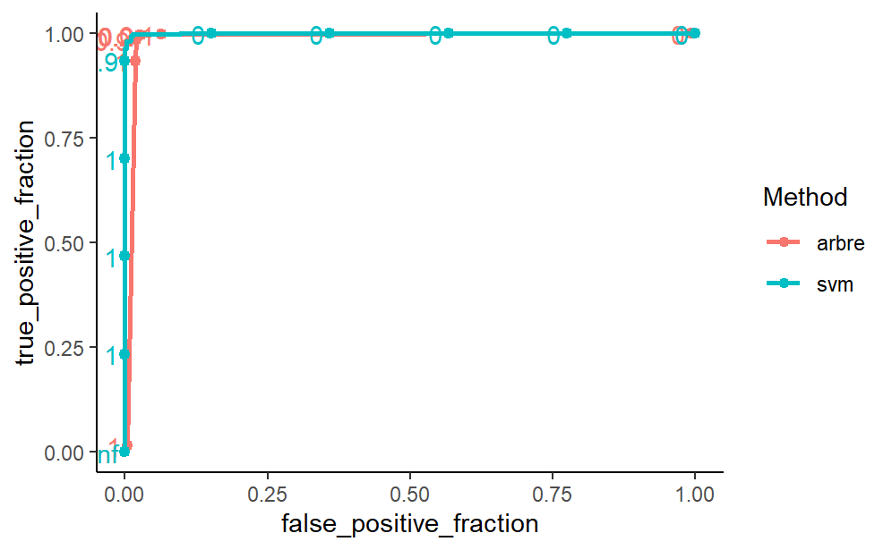

```r
Y1 <- as.numeric(test1$Position)-1
score <- data.frame(svm=prob1[,2],arbre=predict(arbre1,newdata=test1)[,2],Y=Y1)
df <- gather(score,key="Method",value=score,-Y)
ggplot(df)+aes(d=Y,m=score,color=Method)+geom_roc()+theme_classic()
```

apparantly there is no big difference between two models bny comparing the accuracy. Just it has to notice that using decision tree is much faster than svm.

why decision tree is not computaitionally expensive?

” Decision trees algorithms do not compute all possible trees when they fit a tree. If they did they would be solving an NP-hard problem. Decision tree fitting algorithms typically make greedy decisions in the fitting process—at each stage they optimize the sub-problem for finding an optimal split with the data in the given node and the keep moving forward in the fitting process. Also, as you move deeper into the decision tree you have a smaller set of data that has made it to the given node so that you will be optimizing the splitting rule over a smaller subset of data. All of these choices are linear scans of the data in the given node. This is not complicated to do but can become somewhat expensive computationally if you have a large number of observations or a large number of covariates to split on. However, a lot of the work can be split up and sent off to different machines to work on so there are ways to build out your computational architecture to scale up. In general though, the method works fairly quickly on lots of the datasets you see in coursework and in many real world scenarios as well.”

## Prise en compte des milieux de terrain

```r
players_2=players[,c("Position","Crossing", "Finishing","Heading.Accuracy","Short.Passing", "Volleys", "Dribbling", "Curve",              "FK.Accuracy","Long.Passing", "Ball.Control", "Acceleration", "Sprint.Speed","Agility","Reactions","Balance","Shot.Power","Jumping",   "Stamina","Strength","Long.Shots", "Aggression", "Interceptions", "Positioning","Vision","Penalties", "Composure",               "Defensive.Awareness", "Standing.Tackle", "Sliding.Tackle")]

Attack=c("LW", "LF", "RW","RF", "CF", "ST", "CAM")
Defense=c("RB", "RWB", "LB", "LWB", "CB")
Midfielder=c("CAM", "CM", "CDM", "LM", "RM")

index_attack=which(players_2$Position %in%(Attack))
index_defense=which(players_2$Position %in%(Defense))
index_mid=which(players_2$Position %in%(Midfielder))

players_3 <- players_2

players_3[index_attack,"Position"]="A"
players_3[index_defense, "Position"]="D"
players_3[index_mid, "Position"]="M"

players_3=players_3[c(index_attack,index_defense,index_mid),]

players_3 <- na.omit(players_3)
players_3$Position <- as.factor(players_3$Position)

set.seed(1234)
n=length(players_3[,1])
len.app=as.integer(3*n/4)
tirage=sample(seq(1,n),len.app, replace=FALSE)
train=players_3[tirage,]
x_train= train[,2:length(train[1,])]
y_train= train[,1]
test=players_3[-tirage,]
x_test= test[,2:length(test[1,])]
y_test= test[,1]
```

```r
str(players_3)
```

```
'data.frame':   6524 obs. of  30 variables:
 $ Position           : Factor w/ 3 levels "A","D","M": 1 1 1 1 1 1 3 1 1 1 ...
 $ Crossing           : int  68 76 68 69 69 65 56 64 59 50 ...
 $ Finishing          : int  87 72 65 73 75 78 61 61 57 76 ...
 $ Heading.Accuracy   : int  89 45 37 66 58 85 28 37 41 75 ...
 $ Short.Passing      : int  75 74 73 71 72 70 67 66 61 73 ...
 $ Volleys            : int  88 72 55 66 59 73 51 49 51 76 ...
 $ Dribbling          : int  75 84 85 85 79 76 75 80 72 73 ...
 $ Curve              : int  75 81 70 84 64 64 66 58 60 61 ...
 $ FK.Accuracy        : int  76 72 60 56 45 54 70 38 61 30 ...
 $ Long.Passing       : int  52 66 60 67 69 44 53 42 47 35 ...
 $ Ball.Control       : int  79 80 81 83 77 76 73 73 66 75 ...
 $ Acceleration       : int  74 91 86 81 89 79 71 96 94 72 ...
 $ Sprint.Speed       : int  76 91 82 78 87 87 71 91 89 71 ...
 $ Agility            : int  74 86 92 83 89 72 76 95 91 68 ...
```

[output cut: 18 more lines]

### SVM

```r
library(e1071)
```

```r
model <- svm(Position~.,data=train,kernel="radial",gamma=1,cost=1)
```

```r
#tune.3positions.lin <- tune(svm,Position~.,data=train,kernel="linear",ranges=list(cost=c(0.01,0.1,1,10,100,1000)))
#summary(tune.3positions.lin)
```

```r
#tune.3positions.rad <- tune(svm,Position~.,data=train,kernel="radial",ranges=list(cost=c(0.1,1,10,100,1000),gamma=c(0.5,1,2,3,4)))
#summary(tune.3positions.rad)
```

```r
#prev <- predict(tune.3positions.rad$best.model,newdata=test)
#confusionMatrix(data = prev, reference = test$Position)
```

```r
#final.model <- svm(Position~.,data=train,kernel="radial",gamma=0.5,cost=10,decision.values=TRUE,probability=TRUE)
#prob <- predict(final.model,newdata=test,probability=TRUE,decision.values=TRUE)
#prob1 <- attr(prob,"probabilities")
```

```r
gr.svm.poly = expand.grid(C=c(0.0001,0.001,0.01,0.1,1), degree=c(2,3,4,5), scale=c(1))
train.svm.poly = train(Position~.,
                     data = train,
                     method = "svmPoly",
                     trControl = ctrl,
                     tuneGrid = gr.svm.poly)
```

```r
train.svm.poly
```

```
Support Vector Machines with Polynomial Kernel

4893 samples
  29 predictor
   3 classes: 'A', 'D', 'M'

No pre-processing
Resampling: Cross-Validated (10 fold)
Summary of sample sizes: 4404, 4404, 4403, 4404, 4403, 4404, ...
Resampling results across tuning parameters:

  C      degree  Accuracy   Kappa
  1e-04  2       0.8246572  0.7159073
  1e-04  3       0.8551041  0.7698037
 1e-04 4      0.8256688 0.7263089
 1e-04 5      0.8146325 0.7107062
 1e-03 2      0.8559217 0.7709427
 1e-03 3      0.8508071 0.7654431
 1e-03 4      0.8125900 0.7074951
 1e-03 5      0.8138137 0.7094845
 1e-02 2      0.8610263 0.7804103
 1e-02 3      0.8193364 0.7179904
 1e-02 4      0.8144284 0.7103662
 1e-02 5      0.8138137 0.7094845
 1e-01 2      0.8422244 0.7524300
 1e-01 3      0.8189237 0.7180436
 1e-01 4      0.8144284 0.7103662
 1e-01 5      0.8138137 0.7094845
 1e+00 2      0.8138141 0.7092196
 1e+00 3      0.8189237 0.7180436
 1e+00 4      0.8144284 0.7103662
 1e+00 5      0.8138137 0.7094845

Tuning parameter 'scale' was held constant at a value of 1
Accuracy was used to select the optimal model using
 the largest value.
The final values used for the model were degree = 2,
 scale = 1 and C = 0.01.
```

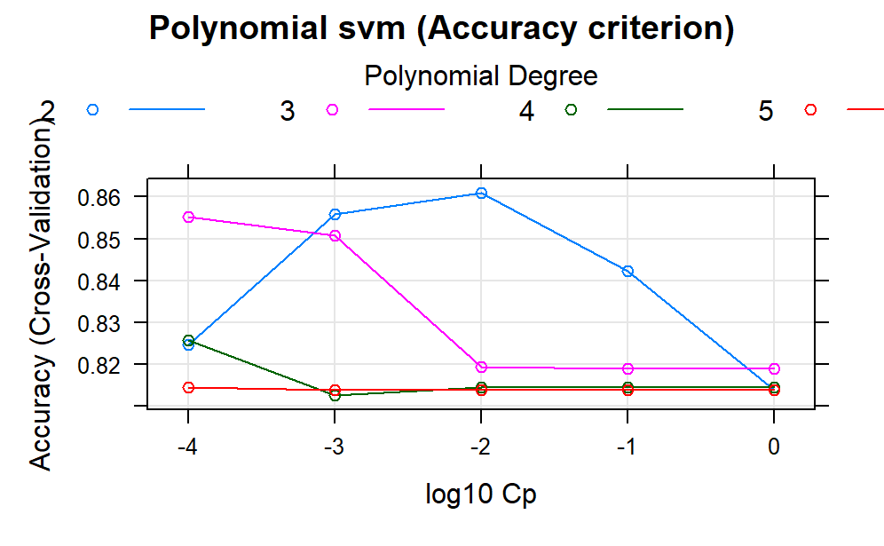

```r
plot(train.svm.poly, metric = "Accuracy", xTrans = log10, xlab = "log10 Cp", main = "Polynomial svm (Accuracy criterion)")
```

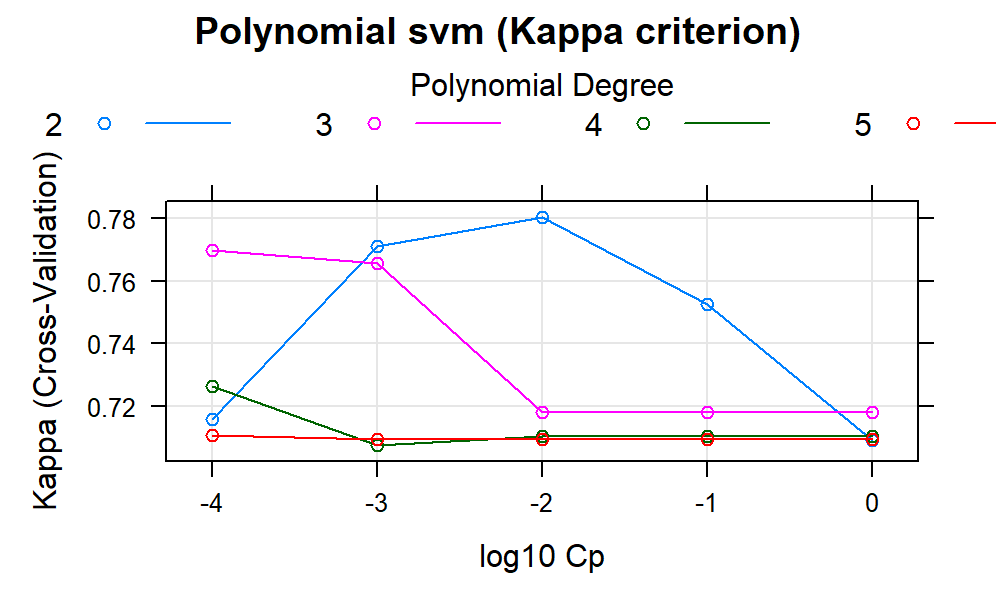

```r
plot(train.svm.poly, metric = "Kappa", xTrans = log10, xlab = "log10 Cp", main = "Polynomial svm (Kappa criterion)")
```

```r
train.svm.poly$finalModel
```

```
Support Vector Machine object of class "ksvm"

SV type: C-svc  (classification)
 parameter : cost C = 0.01

Polynomial kernel function.
 Hyperparameters : degree =  2  scale =  1  offset =  1

Number of Support Vectors : 1748

Objective Function Value : -0.6494 -9.8651 -3.9964
Training error : 0.105866
```

```r
pred.svm.poly <- predict(train.svm.poly,newdata = test)
```